# google play store

1. Import required libraries and read the dataset.

```python
import numpy as np
import pandas as pd
import matplotlib.pyplot as plt
import seaborn as sns
```

```python
df=pd.read_csv(r"C:\Users\sunus\Downloads\Apps_data+(1).csv")
df.head(5)
```

|  | App | Category | Rating | Reviews | Size | Installs | Type | Price | Content Rating | Genres | Last Updated | Current Ver | Android Ver |
| --- | --- | --- | --- | --- | --- | --- | --- | --- | --- | --- | --- | --- | --- |
| 0 | Photo Editor & Candy Camera & Grid & ScrapBook | ART_AND_DESIGN | 4.1 | 159 | 19M | 10,000+ | Free | 0 | Everyone | Art & Design | January 7, 2018 | 1.0.0 | 4.0.3 and up |
| 1 | Coloring book moana | ART_AND_DESIGN | 3.9 | 967 | 14M | 500,000+ | Free | 0 | Everyone | Art & Design;Pretend Play | January 15, 2018 | 2.0.0 | 4.0.3 and up |
| 2 | U Launcher Lite – FREE Live Cool Themes, Hide ... | ART_AND_DESIGN | 4.7 | 87510 | 8.7M | 5,000,000+ | Free | 0 | Everyone | Art & Design | August 1, 2018 | 1.2.4 | 4.0.3 and up |
| 3 | Sketch - Draw & Paint | ART_AND_DESIGN | 4.5 | 215644 | 25M | 50,000,000+ | Free | 0 | Teen | Art & Design | June 8, 2018 | Varies with device | 4.2 and up |
| 4 | Pixel Draw - Number Art Coloring Book | ART_AND_DESIGN | 4.3 | 967 | 2.8M | 100,000+ | Free | 0 | Everyone | Art & Design;Creativity | June 20, 2018 | 1.1 | 4.4 and up |

1. Check the first few samples, shape, info of the data and try to familiarize yourself with different features.

```python
df.shape
```

```
(10841, 13)
```

```python
df.info()
```

```
<class 'pandas.core.frame.DataFrame'>
RangeIndex: 10841 entries, 0 to 10840
Data columns (total 13 columns):
 #   Column          Non-Null Count  Dtype
---  ------          --------------  -----
 0   App             10841 non-null  object
 1   Category        10841 non-null  object
 2   Rating          9367 non-null   float64
 3   Reviews         10841 non-null  object
 4   Size            10841 non-null  object
 5   Installs        10841 non-null  object
 6   Type            10840 non-null  object
 7   Price           10841 non-null  object
 8   Content Rating  10840 non-null  object
 9   Genres          10841 non-null  object
 10  Last Updated    10841 non-null  object
 11  Current Ver     10833 non-null  object
 12  Android Ver     10838 non-null  object
dtypes: float64(1), object(12)
memory usage: 1.1+ MB
```

There are total of 10841 entries 13 columns in a dataframe. Data types are object and float.

1. Check summary statistics of the dataset. List out the columns that need to be worked upon for model building.

```python
df.describe()
```

|  | Rating |
| --- | --- |
| count | 9367.000000 |
| mean | 4.193338 |
| std | 0.537431 |
| min | 1.000000 |
| 25% | 4.000000 |
| 50% | 4.300000 |
| 75% | 4.500000 |
| max | 19.000000 |

```python
df.describe(include='O')
```

|  | App | Category | Reviews | Size | Installs | Type | Price | Content Rating | Genres | Last Updated | Current Ver | Android Ver |
| --- | --- | --- | --- | --- | --- | --- | --- | --- | --- | --- | --- | --- |
| count | 10841 | 10841 | 10841 | 10841 | 10841 | 10840 | 10841 | 10840 | 10841 | 10841 | 10833 | 10838 |
| unique | 9660 | 34 | 6002 | 462 | 22 | 3 | 93 | 6 | 120 | 1378 | 2832 | 33 |
| top | ROBLOX | FAMILY | 0 | Varies with device | 1,000,000+ | Free | 0 | Everyone | Tools | August 3, 2018 | Varies with device | 4.1 and up |
| freq | 9 | 1972 | 596 | 1695 | 1579 | 10039 | 10040 | 8714 | 842 | 326 | 1459 | 2451 |

1. Check if there are any duplicate records in the dataset? if any drop them.

```python
df.duplicated().sum()
```

```
483
```

```python
df=df.drop_duplicates()
```

```python
df.duplicated().sum()
```

```
0
```

1. Check the unique categories of the column 'Category', Is there any invalid category? If yes, drop them.

```python
df['Category'].unique()
```

```
array(['ART_AND_DESIGN', 'AUTO_AND_VEHICLES', 'BEAUTY',
       'BOOKS_AND_REFERENCE', 'BUSINESS', 'COMICS', 'COMMUNICATION',
       'DATING', 'EDUCATION', 'ENTERTAINMENT', 'EVENTS', 'FINANCE',
       'FOOD_AND_DRINK', 'HEALTH_AND_FITNESS', 'HOUSE_AND_HOME',
       'LIBRARIES_AND_DEMO', 'LIFESTYLE', 'GAME', 'FAMILY', 'MEDICAL',
       'SOCIAL', 'SHOPPING', 'PHOTOGRAPHY', 'SPORTS', 'TRAVEL_AND_LOCAL',
       'TOOLS', 'PERSONALIZATION', 'PRODUCTIVITY', 'PARENTING', 'WEATHER',
       'VIDEO_PLAYERS', 'NEWS_AND_MAGAZINES', 'MAPS_AND_NAVIGATION',
       '1.9'], dtype=object)
```

```python
ic=['Invaild Catergory1','Invaild Catergory2']
df = df[~df['Category'].isin(ic)]
df.shape
```

```
(10358, 13)
```

```python
df['Category'].nunique()
```

```
34
```

1. Check if there are missing values present in the column Rating, If any? drop them and and create a new column as 'Rating_category' by converting ratings to high and low categories(>3.5 is high rest low)

```python
df['Rating'].isnull().sum()
```

```
1465
```

```python
df["Rating_Category"]=df["Rating"].apply(lambda x:'high' if x>3.5 else 'low')
```

```python
set(df["Rating_Category"])
```

```
{'high', 'low'}
```

1. Check the distribution of the newly created column 'Rating_category' and comment on the distribution.

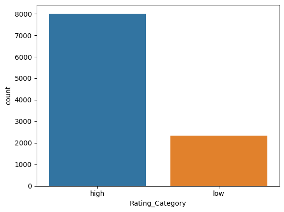

```python
sns.countplot(x='Rating_Category',data=df)
```

```python
df['Rating_Category'].value_counts()
```

```
high    8013
low     2345
Name: Rating_Category, dtype: int64
```

count of people who rated above (high) is more compare to people who rated below (low)

1. Convert the column "Reviews'' to numeric data type and check the presence of outliers in the column and handle the outliers using a transformation approach.(Hint: Use log transformation)

```python
df["Reviews"]=pd.to_numeric(df["Reviews"],errors='coerce')
df["Reviews"]
```

```
0           159.0
1           967.0
2         87510.0
3        215644.0
4           967.0
           ...
10836        38.0
10837         4.0
10838         3.0
10839       114.0
10840    398307.0
Name: Reviews, Length: 10358, dtype: float64
```

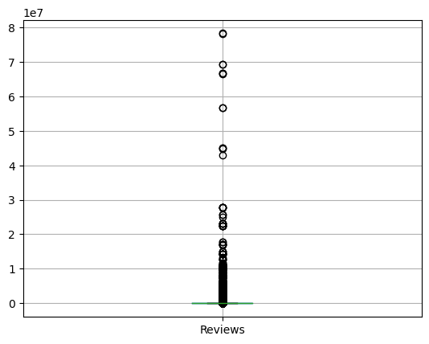

```python
df.boxplot(column="Reviews")
plt.show()
```

```python
Q1 = df['Reviews'].quantile(0.25)
Q3 = df['Reviews'].quantile(0.75)
IQR = Q3 - Q1
lower_bound = Q1 - 1.5 * IQR
upper_bound = Q3 + 1.5 * IQR

outliers = df[(df['Reviews'] < lower_bound) | (df['Reviews'] > upper_bound)]


outliers
```

|  | App | Category | Rating | Reviews | Size | Installs | Type | Price | Content Rating | Genres | Last Updated | Current Ver | Android Ver | Rating_Category |
| --- | --- | --- | --- | --- | --- | --- | --- | --- | --- | --- | --- | --- | --- | --- |
| 3 | Sketch - Draw & Paint | ART_AND_DESIGN | 4.5 | 215644.0 | 25M | 50,000,000+ | Free | 0 | Teen | Art & Design | June 8, 2018 | Varies with device | 4.2 and up | high |
| 18 | FlipaClip - Cartoon animation | ART_AND_DESIGN | 4.3 | 194216.0 | 39M | 5,000,000+ | Free | 0 | Everyone | Art & Design | August 3, 2018 | 2.2.5 | 4.0.3 and up | high |
| 19 | ibis Paint X | ART_AND_DESIGN | 4.6 | 224399.0 | 31M | 10,000,000+ | Free | 0 | Everyone | Art & Design | July 30, 2018 | 5.5.4 | 4.1 and up | high |
| 42 | Textgram - write on photos | ART_AND_DESIGN | 4.4 | 295221.0 | Varies with device | 10,000,000+ | Free | 0 | Everyone | Art & Design | July 30, 2018 | Varies with device | Varies with device | high |
| 45 | Canva: Poster, banner, card maker & graphic de... | ART_AND_DESIGN | 4.7 | 174531.0 | 24M | 10,000,000+ | Free | 0 | Everyone | Art & Design | July 31, 2018 | 1.6.1 | 4.1 and up | high |
| ... | ... | ... | ... | ... | ... | ... | ... | ... | ... | ... | ... | ... | ... | ... |
| 10740 | PhotoFunia | PHOTOGRAPHY | 4.3 | 316378.0 | 4.4M | 10,000,000+ | Free | 0 | Everyone | Photography | June 3, 2017 | 4.0.7.0 | 2.3 and up | high |
| 10781 | Modern Strike Online | GAME | 4.3 | 834117.0 | 44M | 10,000,000+ | Free | 0 | Teen | Action | July 30, 2018 | 1.25.4 | 4.1 and up | high |
| 10784 | Big Hunter | GAME | 4.3 | 245455.0 | 84M | 10,000,000+ | Free | 0 | Everyone 10+ | Action | May 31, 2018 | 2.8.6 | 4.0 and up | high |
| 10809 | Castle Clash: RPG War and Strategy FR | FAMILY | 4.7 | 376223.0 | 24M | 1,000,000+ | Free | 0 | Everyone | Strategy | July 18, 2018 | 1.4.2 | 4.1 and up | high |
| 10840 | iHoroscope - 2018 Daily Horoscope & Astrology | LIFESTYLE | 4.5 | 398307.0 | 19M | 10,000,000+ | Free | 0 | Everyone | Lifestyle | July 25, 2018 | Varies with device | Varies with device | high |

1870 rows × 14 columns

```python
df['Reviews'] = np.log1p(df['Reviews'])
```

1. The column 'Size' contains alphanumeric values, treat the non numeric data and convert the column into suitable data type. (hint: Replace M with 1 million and K with 1 thousand, and drop the entries where size='Varies with device')

```python
df['Size']
```

```
0                       19M
1                       14M
2                      8.7M
3                       25M
4                      2.8M
                ...
10836                   53M
10837                  3.6M
10838                  9.5M
10839    Varies with device
10840                   19M
Name: Size, Length: 10358, dtype: object
```

```python
df['Size'] = df['Size'].replace('Varies with device', np.nan)
df['Size'] = df['Size'].str.replace('M', 'e6').str.replace('K', 'e3')

df['Size'] = pd.to_numeric(df['Size'], errors='coerce')
df = df.dropna(subset=['Size'])
```

```python
df
```

|  | App | Category | Rating | Reviews | Size | Installs | Type | Price | Content Rating | Genres | Last Updated | Current Ver | Android Ver | Rating_Category |
| --- | --- | --- | --- | --- | --- | --- | --- | --- | --- | --- | --- | --- | --- | --- |
| 0 | Photo Editor & Candy Camera & Grid & ScrapBook | ART_AND_DESIGN | 4.1 | 5.075174 | 19000000.0 | 10,000+ | Free | 0 | Everyone | Art & Design | January 7, 2018 | 1.0.0 | 4.0.3 and up | high |
| 1 | Coloring book moana | ART_AND_DESIGN | 3.9 | 6.875232 | 14000000.0 | 500,000+ | Free | 0 | Everyone | Art & Design;Pretend Play | January 15, 2018 | 2.0.0 | 4.0.3 and up | high |
| 2 | U Launcher Lite – FREE Live Cool Themes, Hide ... | ART_AND_DESIGN | 4.7 | 11.379520 | 8700000.0 | 5,000,000+ | Free | 0 | Everyone | Art & Design | August 1, 2018 | 1.2.4 | 4.0.3 and up | high |
| 3 | Sketch - Draw & Paint | ART_AND_DESIGN | 4.5 | 12.281389 | 25000000.0 | 50,000,000+ | Free | 0 | Teen | Art & Design | June 8, 2018 | Varies with device | 4.2 and up | high |
| 4 | Pixel Draw - Number Art Coloring Book | ART_AND_DESIGN | 4.3 | 6.875232 | 2800000.0 | 100,000+ | Free | 0 | Everyone | Art & Design;Creativity | June 20, 2018 | 1.1 | 4.4 and up | high |
| ... | ... | ... | ... | ... | ... | ... | ... | ... | ... | ... | ... | ... | ... | ... |
| 10835 | FR Forms | BUSINESS | NaN | 0.000000 | 9600000.0 | 10+ | Free | 0 | Everyone | Business | September 29, 2016 | 1.1.5 | 4.0 and up | low |
| 10836 | Sya9a Maroc - FR | FAMILY | 4.5 | 3.663562 | 53000000.0 | 5,000+ | Free | 0 | Everyone | Education | July 25, 2017 | 1.48 | 4.1 and up | high |
| 10837 | Fr. Mike Schmitz Audio Teachings | FAMILY | 5.0 | 1.609438 | 3600000.0 | 100+ | Free | 0 | Everyone | Education | July 6, 2018 | 1.0 | 4.1 and up | high |
| 10838 | Parkinson Exercices FR | MEDICAL | NaN | 1.386294 | 9500000.0 | 1,000+ | Free | 0 | Everyone | Medical | January 20, 2017 | 1.0 | 2.2 and up | low |
| 10840 | iHoroscope - 2018 Daily Horoscope & Astrology | LIFESTYLE | 4.5 | 12.894981 | 19000000.0 | 10,000,000+ | Free | 0 | Everyone | Lifestyle | July 25, 2018 | Varies with device | Varies with device | high |

8516 rows × 14 columns

1. Check the column 'Installs', treat the unwanted characters and convert the column into a suitable data type.

```python
df['Installs'].info()
```

```
<class 'pandas.core.series.Series'>
Int64Index: 8516 entries, 0 to 10840
Series name: Installs
Non-Null Count  Dtype
--------------  -----
8516 non-null   object
dtypes: object(1)
memory usage: 133.1+ KB
```

```python
df['Installs'] = df['Installs'].str.replace(',', '').str.replace('+', '')

df['Installs'] = pd.to_numeric(df['Installs'], errors='coerce')
df
```

|  | App | Category | Rating | Reviews | Size | Installs | Type | Price | Content Rating | Genres | Last Updated | Current Ver | Android Ver | Rating_Category |
| --- | --- | --- | --- | --- | --- | --- | --- | --- | --- | --- | --- | --- | --- | --- |
| 0 | Photo Editor & Candy Camera & Grid & ScrapBook | ART_AND_DESIGN | 4.1 | 5.075174 | 19000000.0 | 10000 | Free | 0 | Everyone | Art & Design | January 7, 2018 | 1.0.0 | 4.0.3 and up | high |
| 1 | Coloring book moana | ART_AND_DESIGN | 3.9 | 6.875232 | 14000000.0 | 500000 | Free | 0 | Everyone | Art & Design;Pretend Play | January 15, 2018 | 2.0.0 | 4.0.3 and up | high |
| 2 | U Launcher Lite – FREE Live Cool Themes, Hide ... | ART_AND_DESIGN | 4.7 | 11.379520 | 8700000.0 | 5000000 | Free | 0 | Everyone | Art & Design | August 1, 2018 | 1.2.4 | 4.0.3 and up | high |
| 3 | Sketch - Draw & Paint | ART_AND_DESIGN | 4.5 | 12.281389 | 25000000.0 | 50000000 | Free | 0 | Teen | Art & Design | June 8, 2018 | Varies with device | 4.2 and up | high |
| 4 | Pixel Draw - Number Art Coloring Book | ART_AND_DESIGN | 4.3 | 6.875232 | 2800000.0 | 100000 | Free | 0 | Everyone | Art & Design;Creativity | June 20, 2018 | 1.1 | 4.4 and up | high |
| ... | ... | ... | ... | ... | ... | ... | ... | ... | ... | ... | ... | ... | ... | ... |
| 10835 | FR Forms | BUSINESS | NaN | 0.000000 | 9600000.0 | 10 | Free | 0 | Everyone | Business | September 29, 2016 | 1.1.5 | 4.0 and up | low |
| 10836 | Sya9a Maroc - FR | FAMILY | 4.5 | 3.663562 | 53000000.0 | 5000 | Free | 0 | Everyone | Education | July 25, 2017 | 1.48 | 4.1 and up | high |
| 10837 | Fr. Mike Schmitz Audio Teachings | FAMILY | 5.0 | 1.609438 | 3600000.0 | 100 | Free | 0 | Everyone | Education | July 6, 2018 | 1.0 | 4.1 and up | high |
| 10838 | Parkinson Exercices FR | MEDICAL | NaN | 1.386294 | 9500000.0 | 1000 | Free | 0 | Everyone | Medical | January 20, 2017 | 1.0 | 2.2 and up | low |
| 10840 | iHoroscope - 2018 Daily Horoscope & Astrology | LIFESTYLE | 4.5 | 12.894981 | 19000000.0 | 10000000 | Free | 0 | Everyone | Lifestyle | July 25, 2018 | Varies with device | Varies with device | high |

8516 rows × 14 columns

1. Check the column 'Price' , remove the unwanted characters and convert the column into a suitable data type.

```python
df['Price']
```

```
0        0
1        0
2        0
3        0
4        0
        ..
10835    0
10836    0
10837    0
10838    0
10840    0
Name: Price, Length: 8516, dtype: object
```

```python
df["Price"]=df["Price"].str.replace('$','')
df['Price']=pd.to_numeric(df['Price'],errors='coerce')
df
```

|  | App | Category | Rating | Reviews | Size | Installs | Type | Price | Content Rating | Genres | Last Updated | Current Ver | Android Ver | Rating_Category |
| --- | --- | --- | --- | --- | --- | --- | --- | --- | --- | --- | --- | --- | --- | --- |
| 0 | Photo Editor & Candy Camera & Grid & ScrapBook | ART_AND_DESIGN | 4.1 | 5.075174 | 19000000.0 | 10000 | Free | 0.0 | Everyone | Art & Design | January 7, 2018 | 1.0.0 | 4.0.3 and up | high |
| 1 | Coloring book moana | ART_AND_DESIGN | 3.9 | 6.875232 | 14000000.0 | 500000 | Free | 0.0 | Everyone | Art & Design;Pretend Play | January 15, 2018 | 2.0.0 | 4.0.3 and up | high |
| 2 | U Launcher Lite – FREE Live Cool Themes, Hide ... | ART_AND_DESIGN | 4.7 | 11.379520 | 8700000.0 | 5000000 | Free | 0.0 | Everyone | Art & Design | August 1, 2018 | 1.2.4 | 4.0.3 and up | high |
| 3 | Sketch - Draw & Paint | ART_AND_DESIGN | 4.5 | 12.281389 | 25000000.0 | 50000000 | Free | 0.0 | Teen | Art & Design | June 8, 2018 | Varies with device | 4.2 and up | high |
| 4 | Pixel Draw - Number Art Coloring Book | ART_AND_DESIGN | 4.3 | 6.875232 | 2800000.0 | 100000 | Free | 0.0 | Everyone | Art & Design;Creativity | June 20, 2018 | 1.1 | 4.4 and up | high |
| ... | ... | ... | ... | ... | ... | ... | ... | ... | ... | ... | ... | ... | ... | ... |
| 10835 | FR Forms | BUSINESS | NaN | 0.000000 | 9600000.0 | 10 | Free | 0.0 | Everyone | Business | September 29, 2016 | 1.1.5 | 4.0 and up | low |
| 10836 | Sya9a Maroc - FR | FAMILY | 4.5 | 3.663562 | 53000000.0 | 5000 | Free | 0.0 | Everyone | Education | July 25, 2017 | 1.48 | 4.1 and up | high |
| 10837 | Fr. Mike Schmitz Audio Teachings | FAMILY | 5.0 | 1.609438 | 3600000.0 | 100 | Free | 0.0 | Everyone | Education | July 6, 2018 | 1.0 | 4.1 and up | high |
| 10838 | Parkinson Exercices FR | MEDICAL | NaN | 1.386294 | 9500000.0 | 1000 | Free | 0.0 | Everyone | Medical | January 20, 2017 | 1.0 | 2.2 and up | low |
| 10840 | iHoroscope - 2018 Daily Horoscope & Astrology | LIFESTYLE | 4.5 | 12.894981 | 19000000.0 | 10000000 | Free | 0.0 | Everyone | Lifestyle | July 25, 2018 | Varies with device | Varies with device | high |

8516 rows × 14 columns

1. Drop the columns which you think redundant for the analysis.(suggestion: drop column 'rating', since we created a new feature from it (i.e. rating_category) and the columns 'App', 'Rating' ,'Genres','Last Updated', 'Current Ver','Android Ver' columns since which are redundant for our analysis)

```python
df.columns
```

```
Index(['App', 'Category', 'Rating', 'Reviews', 'Size', 'Installs', 'Type',
       'Price', 'Content Rating', 'Genres', 'Last Updated', 'Current Ver',
       'Android Ver', 'Rating_Category'],
      dtype='object')
```

```python
ab=['App', 'Rating', 'Genres', 'Last Updated', 'Current Ver', 'Android Ver']
df.drop(ab,axis=1)
```

|  | Category | Reviews | Size | Installs | Type | Price | Content Rating | Rating_Category |
| --- | --- | --- | --- | --- | --- | --- | --- | --- |
| 0 | ART_AND_DESIGN | 5.075174 | 19000000.0 | 10000 | Free | 0.0 | Everyone | high |
| 1 | ART_AND_DESIGN | 6.875232 | 14000000.0 | 500000 | Free | 0.0 | Everyone | high |
| 2 | ART_AND_DESIGN | 11.379520 | 8700000.0 | 5000000 | Free | 0.0 | Everyone | high |
| 3 | ART_AND_DESIGN | 12.281389 | 25000000.0 | 50000000 | Free | 0.0 | Teen | high |
| 4 | ART_AND_DESIGN | 6.875232 | 2800000.0 | 100000 | Free | 0.0 | Everyone | high |
| ... | ... | ... | ... | ... | ... | ... | ... | ... |
| 10835 | BUSINESS | 0.000000 | 9600000.0 | 10 | Free | 0.0 | Everyone | low |
| 10836 | FAMILY | 3.663562 | 53000000.0 | 5000 | Free | 0.0 | Everyone | high |
| 10837 | FAMILY | 1.609438 | 3600000.0 | 100 | Free | 0.0 | Everyone | high |
| 10838 | MEDICAL | 1.386294 | 9500000.0 | 1000 | Free | 0.0 | Everyone | low |
| 10840 | LIFESTYLE | 12.894981 | 19000000.0 | 10000000 | Free | 0.0 | Everyone | high |

8516 rows × 8 columns

1. Encode the categorical columns.

```python
df.info()
```

```
<class 'pandas.core.frame.DataFrame'>
Int64Index: 8516 entries, 0 to 10840
Data columns (total 14 columns):
 #   Column           Non-Null Count  Dtype
---  ------           --------------  -----
 0   App              8516 non-null   object
 1   Category         8516 non-null   object
 2   Rating           7167 non-null   float64
 3   Reviews          8516 non-null   float64
 4   Size             8516 non-null   float64
 5   Installs         8516 non-null   int64
 6   Type             8516 non-null   object
 7   Price            8516 non-null   float64
 8   Content Rating   8516 non-null   object
 9   Genres           8516 non-null   object
 10  Last Updated     8516 non-null   object
 11  Current Ver      8512 non-null   object
 12  Android Ver      8514 non-null   object
 13  Rating_Category  8516 non-null   object
dtypes: float64(4), int64(1), object(9)
memory usage: 998.0+ KB
```

```python
from sklearn.preprocessing import LabelEncoder
label_encoder = LabelEncoder()
df['Category'] = label_encoder.fit_transform(df['Category'])
df['Rating_Category'] = label_encoder.fit_transform(df['Rating_Category'])
df['Rating_Category']
```

```
0        0
1        0
2        0
3        0
4        0
        ..
10835    1
10836    0
10837    0
10838    1
10840    0
Name: Rating_Category, Length: 8516, dtype: int32
```

```python
categorical_columns = ['Type', 'Content Rating']
df_encoded = pd.get_dummies(df, columns=categorical_columns)
df_encoded
```

|  | App | Category | Rating | Reviews | Size | Installs | Price | Genres | Last Updated | Current Ver | Android Ver | Rating_Category | Type_Free | Type_Paid | Content Rating_Adults only 18+ | Content Rating_Everyone | Content Rating_Everyone 10+ | Content Rating_Mature 17+ | Content Rating_Teen | Content Rating_Unrated |
| --- | --- | --- | --- | --- | --- | --- | --- | --- | --- | --- | --- | --- | --- | --- | --- | --- | --- | --- | --- | --- |
| 0 | Photo Editor & Candy Camera & Grid & ScrapBook | 0 | 4.1 | 5.075174 | 19000000.0 | 10000 | 0.0 | Art & Design | January 7, 2018 | 1.0.0 | 4.0.3 and up | 0 | 1 | 0 | 0 | 1 | 0 | 0 | 0 | 0 |
| 1 | Coloring book moana | 0 | 3.9 | 6.875232 | 14000000.0 | 500000 | 0.0 | Art & Design;Pretend Play | January 15, 2018 | 2.0.0 | 4.0.3 and up | 0 | 1 | 0 | 0 | 1 | 0 | 0 | 0 | 0 |
| 2 | U Launcher Lite – FREE Live Cool Themes, Hide ... | 0 | 4.7 | 11.379520 | 8700000.0 | 5000000 | 0.0 | Art & Design | August 1, 2018 | 1.2.4 | 4.0.3 and up | 0 | 1 | 0 | 0 | 1 | 0 | 0 | 0 | 0 |
| 3 | Sketch - Draw & Paint | 0 | 4.5 | 12.281389 | 25000000.0 | 50000000 | 0.0 | Art & Design | June 8, 2018 | Varies with device | 4.2 and up | 0 | 1 | 0 | 0 | 0 | 0 | 0 | 1 | 0 |
| 4 | Pixel Draw - Number Art Coloring Book | 0 | 4.3 | 6.875232 | 2800000.0 | 100000 | 0.0 | Art & Design;Creativity | June 20, 2018 | 1.1 | 4.4 and up | 0 | 1 | 0 | 0 | 1 | 0 | 0 | 0 | 0 |
| ... | ... | ... | ... | ... | ... | ... | ... | ... | ... | ... | ... | ... | ... | ... | ... | ... | ... | ... | ... | ... |
| 10835 | FR Forms | 4 | NaN | 0.000000 | 9600000.0 | 10 | 0.0 | Business | September 29, 2016 | 1.1.5 | 4.0 and up | 1 | 1 | 0 | 0 | 1 | 0 | 0 | 0 | 0 |
| 10836 | Sya9a Maroc - FR | 11 | 4.5 | 3.663562 | 53000000.0 | 5000 | 0.0 | Education | July 25, 2017 | 1.48 | 4.1 and up | 0 | 1 | 0 | 0 | 1 | 0 | 0 | 0 | 0 |
| 10837 | Fr. Mike Schmitz Audio Teachings | 11 | 5.0 | 1.609438 | 3600000.0 | 100 | 0.0 | Education | July 6, 2018 | 1.0 | 4.1 and up | 0 | 1 | 0 | 0 | 1 | 0 | 0 | 0 | 0 |
| 10838 | Parkinson Exercices FR | 20 | NaN | 1.386294 | 9500000.0 | 1000 | 0.0 | Medical | January 20, 2017 | 1.0 | 2.2 and up | 1 | 1 | 0 | 0 | 1 | 0 | 0 | 0 | 0 |
| 10840 | iHoroscope - 2018 Daily Horoscope & Astrology | 18 | 4.5 | 12.894981 | 19000000.0 | 10000000 | 0.0 | Lifestyle | July 25, 2018 | Varies with device | Varies with device | 0 | 1 | 0 | 0 | 1 | 0 | 0 | 0 | 0 |

8516 rows × 20 columns

1. Segregate the target and independent features (Hint: Use Rating_category as the target)

```python
df['Rating_Category']
independent_column=df_encoded.drop('Rating_Category',axis=1)
```

1. Split the dataset into train and test.

```python
from sklearn.model_selection import train_test_split
X_train, X_test, y_train, y_test = train_test_split(independent_column, df_encoded['Rating_Category'], test_size=0.2, random_state=42)
```

1. Standardize the data, so that the values are within a particular range.

```python
from sklearn.preprocessing import StandardScaler
scaler = StandardScaler()
X_train_scaled = scaler.fit_transform(X_train)
X_test_scaled = scaler.transform(X_test)

print("Standardized X_train:")
print(pd.DataFrame(X_train_scaled, columns=X_train.columns))
print("\nStandardized X_test:")
print(pd.DataFrame(X_test_scaled, columns=X_test.columns))
```

[output not shown]

[output cut: 22 more lines]

[output not shown]